# Data transakcii v pekarni

Ja

8 decembra 2018

# Toto je datova vzorka transakcii z predaje pekarne

Tuto vzorku som ziskal na webovej stranke kaggle.com v nej analyzujem ako sa vyvijal predaj jednotlivych poloziek za sledovany cas. Cielom tohto zadania je zistit najpredavanejsie polozky, ich kombinaciu pocas jednej transakcii a tak navrhnut katalog, v ktorom budu najziadanejsie polozky a ich zlavy tak nastavene, aby boli spokojni aj zakaznici a aj predajca, aby bol najziskovejsi

```r
getwd()
```

```
## [1] "C:/Users/User/Documents/GIT/BC"
```

```r
transakcie = read.csv("BreadBasket_DMS.csv")
A = summary(transakcie$Item)
B = as.logical(summary(transakcie$Item)> 590)
C = levels(transakcie$Item)
pomocne = data.frame(A,B,C)

Bread = summary(droplevels(transakcie[which(transakcie$Item=="Bread"),4]))
Cake = summary(droplevels(transakcie[which(transakcie$Item=="Cake"),4]))
Coffee= summary(droplevels(transakcie[which(transakcie$Item=="Coffee"),4]))
Medialuna= summary(droplevels(transakcie[which(transakcie$Item=="Medialuna"),4]))
NONE= summary(droplevels(transakcie[which(transakcie$Item=="NONE"),4]))
Pastry= summary(droplevels(transakcie[which(transakcie$Item=="Pastry"),4]))
Sandwich= summary(droplevels(transakcie[which(transakcie$Item=="Sandwich"),4]))
Tea= summary(droplevels(transakcie[which(transakcie$Item=="Tea"),4]))




Nesledovane = sum(pomocne[pomocne$B==FALSE,1])
sum(pomocne[pomocne$B==FALSE,1])
```

```
## [1] 7008
```

```r
for (i in 1:7008) {
  Nesledovane[i]= "Ostatne"
}
Nesledovane = as.factor(Nesledovane)

Nesledovane = summary(Nesledovane)


sledovane = c(Bread,Cake,Coffee,Medialuna,NONE,Pastry,Sandwich,Tea,Nesledovane)
```

Najprv som si nacital data z pripravenej datovej vzorky ulozenej v .csv potom pomocou summary nad stlpcom Item som zistil najpredavanejsie polozky. Tie agregacie nad stlcpom Item som vyselektoval do noveho data.frame-u pomocne. Do pomocne som pod pismenom A ulozil pocet jednotlivych poloziek. Do B su nacitane hodnoty TRUE alebo FALSE, ktore bud splnali podmienku predaja nad 590 alebo nie. 590 hodnotu som si vybral, preto lebo mala mnozina tejto tabulky presahovala za celkove sledovvane obdobie tuto uvedenu hodnotu. Ked som spravil spravil rozdiel hodnot medzi najpredavanejsimi polozkami (nad 590) a ostatnymi tak mi vysiel vysledok okolo 7008 poloziek, ktore som nikam nezaradil, tak som spravil cyklus v ktorom som priradil premennej nesledovane n-krat Ostatne a potom som premenil typ premennej z character na typ faktor. Do premennej sledovane som ulozil vytriedene polozky. Vytvoril som si premennu pct, v ktorej som vypocital percentualne rodelenie dat podla poloziek. V data frame-i sledovane_1 su ulozene zosumarizovane hodnoty A - levely faktorov vytriedenych poloziek, B - pocty jednotlivych levelov, C - percenta. Tento data frame bol vychodiskovym na vykreslenie nasledujucich grafov.

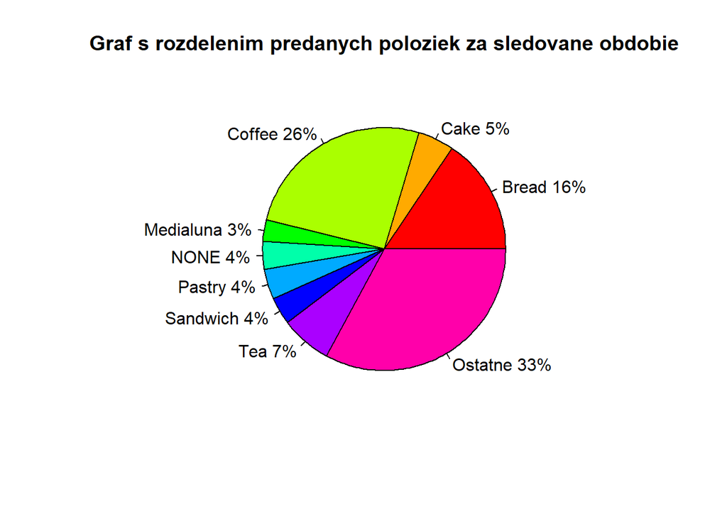

```r
pct = round(sledovane/sum(sledovane)*100)
sledovane_1 = data.frame(A = c("Bread","Cake","Coffee","Medialuna","NONE","Pastry","Sandwich","Tea","Ostatne"), B=sledovane, C=pct)
j = paste(sledovane_1$A, sledovane_1$C, sep = " ")
j = paste(j, "%", sep = "")
pie(sledovane_1$B, labels = j, col = rainbow(length(sledovane_1$B)), main = "Graf s rozdelenim predanych poloziek za sledovane obdobie")
```

```r
#barplot(sledovane, col = rainbow(length(sledovane)))
```

[figure not shown]

Barplot najpredavanejsich poloziek

Tento graf obsahuje na y-osy pocet celkovo predanych poloziek daneho typu a x-os nazvy tych poloziek.

Podla vyselektovanych dat sme mohli postrehnut, ze najpredavanejsie polozky su Chlieb, kava, kolac a caj.

```r
library(lubridate)
spojeneTabulky_1 = readRDS("final.rda")
summary(spojeneTabulky_1)
```

```
##          Date             Time        Transaction        Item
##  2017-02-04:  302   12:07:39:   16   Min.   :   1   Coffee :5471
##  2016-11-05:  283   10:45:21:   13   1st Qu.:2548   Bread  :3325
##  2017-03-04:  265   10:55:19:   13   Median :5067   Tea    :1435
##  2017-03-25:  254   14:38:01:   13   Mean   :4952   Cake   :1025
##  2017-01-28:  243   13:43:08:   12   3rd Qu.:7329   Pastry : 856
##  2017-02-18:  240   14:19:47:   12   Max.   :9684   NONE   : 786
##  (Other)   :19706   (Other) :21214                  (Other):8395
##       Ind              Dni       hms.Minuty..minutes hms.Hodiny..hour
##  Min.   :1.000   Pondelok:2731   Min.   :   1        Min.   : 1.00
##  1st Qu.:2.000   Stvrtok :3115   1st Qu.:2253        1st Qu.:10.00
##  Median :4.000   Utorok  :2986   Median :4251        Median :12.00
##  Mean   :3.932   Streda  :4104   Mean   :4206        Mean   :12.25
##  3rd Qu.:6.000   Piatok  :2559   3rd Qu.:6149        3rd Qu.:14.00
##  Max.   :7.000   Sobota  :3125   Max.   :8240        Max.   :23.00
##                  Nedela  :2673
##     Mesiace            Roky       IndexPolozky
##  Min.   : 1.000   Min.   :2016   Min.   :    1
##  1st Qu.: 2.000   1st Qu.:2016   1st Qu.: 5324
##  Median : 3.000   Median :2017   Median :10647
##  Mean   : 5.905   Mean   :2017   Mean   :10647
##  3rd Qu.:11.000   3rd Qu.:2017   3rd Qu.:15970
##  Max.   :12.000   Max.   :2017   Max.   :21293
##
```

Pri predaji je dolezity aj cas predaja, takze pomocou kniznice lubridate som si vytriedil dni v mesiaci a podla kalendara som si nastavil nazvi dni v mesiaci, aby som na nasledujucich grafoch znazornil suvislosti medzi predajom dnom v tyzdni. Pomocou prikazu relevel som preusporiadal dni v tyzdni.

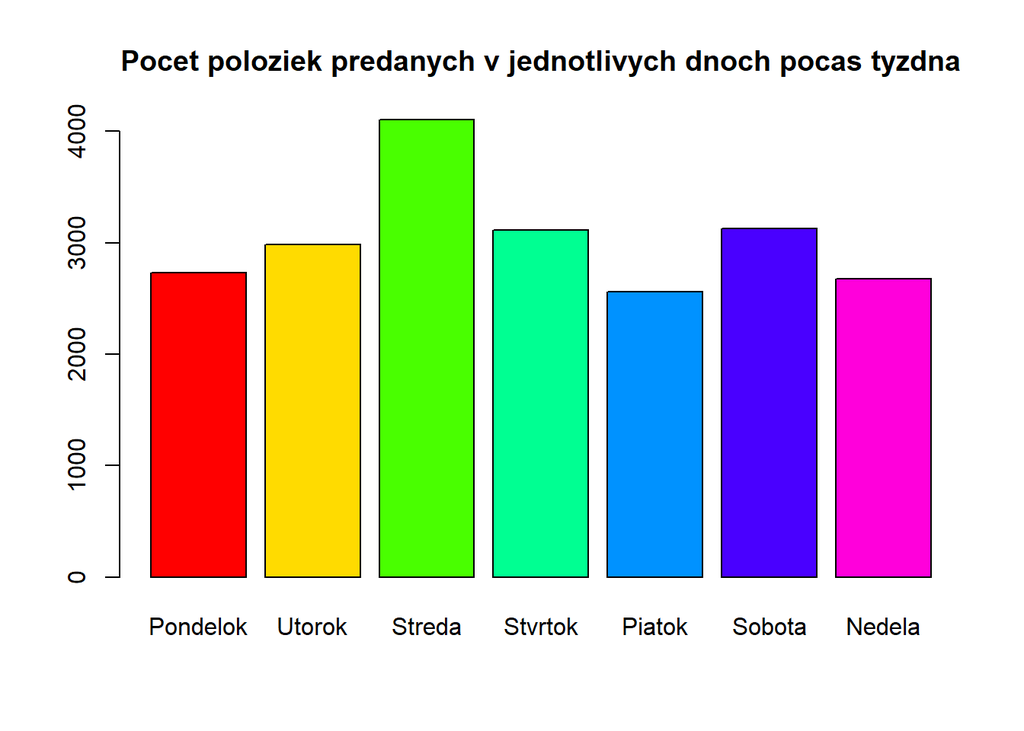

```r
spojeneTabulky_1$Dni = relevel(spojeneTabulky_1$Dni, "Nedela")
spojeneTabulky_1$Dni = relevel(spojeneTabulky_1$Dni, "Sobota")
spojeneTabulky_1$Dni = relevel(spojeneTabulky_1$Dni, "Piatok")
spojeneTabulky_1$Dni = relevel(spojeneTabulky_1$Dni, "Stvrtok")
spojeneTabulky_1$Dni = relevel(spojeneTabulky_1$Dni, "Streda")
spojeneTabulky_1$Dni = relevel(spojeneTabulky_1$Dni, "Utorok")
spojeneTabulky_1$Dni = relevel(spojeneTabulky_1$Dni, "Pondelok")
Dni_2 = summary(spojeneTabulky_1$Dni)
barplot(Dni_2,col = rainbow(length(Dni_2)), main = "Pocet poloziek predanych v jednotlivych dnoch pocas tyzdna")
```

Z tohto grafu vyplyva, ze najviac poloziek sa preda cez tyzden v stredu a cez vikend v sobotu.

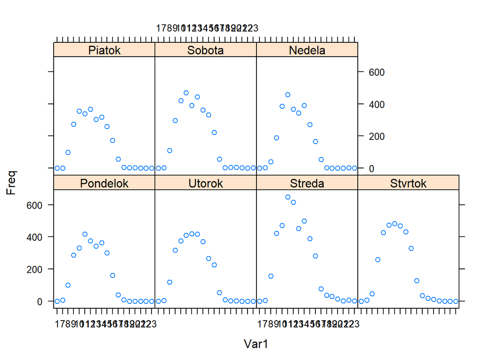

```r
library(lattice)
opilun = data.frame(table(spojeneTabulky_1$hms.Hodiny..hour,spojeneTabulky_1$Dni))
najpredavanejsie_casy = table(spojeneTabulky_1$Item,spojeneTabulky_1$hms.Hodiny..hour)
najpredavanejsie_casy = data.frame(najpredavanejsie_casy)
xyplot(Freq~ Var1| Var2, data=opilun)
```

Z uvedeneho grafu vyplyva to, ze pracovna doba predaja je od 7:00 rana do 1:00 nasledujuceho dna. Najpredavanejsie casy pocas tyzdna su vo vsetkych dnoch okolo obeda medzi 11:00 a 14:00 najviac samozrejme v Stredu ako sme sa dozvedeli v predchadzajucich grafoch.

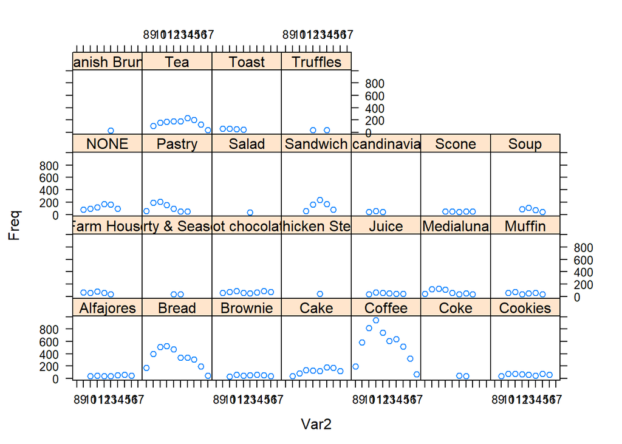

```r
G = najpredavanejsie_casy[which(najpredavanejsie_casy$Freq>33),1:3]
G$Var1 = droplevels(G$Var1)
xyplot(Freq~ Var2| Var1, data=G)
```

Dalej na tychto grafoch sme zistili, ze kava sa predava najviac z rannych hodin a chlieb sa predava okolo 11:00 a 12:00 hodiny

## Modelovanie

V tejto casti na zaklade spoznanych dat a sa pokusime namodelovat urcite vysledky.

### Naivny Bayes

Na dalsich algoritmoch budem skusat modelovat takto roztriedene data. Najprv nastavim vzorkovanie na hodnotu napr. 200 Do premennej Vzorka som ulozil index-i na rotriedene data, na trenovaciu a testovaciu cast. Rozdelenie bolo v pomere 70% ku 30%. Vytvoril som pomocny data.frame v ktorom som spojeneTabulky_1_1.tren vynechal cielovy atribut v tomto pripade roztriedene polozky(napoje, Sladkosti a pod.) do data.frame-u spojeneTabulky_1_1.tren_spoj som uviedeol stlpec sledovaneho atributu. Pouzil som kniznicu e1071, do premennej klasifikacia.trenovacia som pouzil funkciu naiveBayes a do argumentu som dal data.frame bez cieloveho atributu a s cielovym. Vykreslil som si kontigencnu tabulku a vysledok som zapisal do pomocneho data.frame-u vyhodnotenie a z tohto data.frame-u som vypocital celkovu uspesnost za trenovaciu cast. Co sa tyka testovacej mnoziny tak som do funkcie predict za argument newdata pridal testovaciu cast a ostatny postup bol obdobny.

```r
set.seed(200)
Vzorka = sample(2,nrow(spojeneTabulky_1_1),replace = TRUE, prob = c(0.7,0.3))

spojeneTabulky_1_1.tren = spojeneTabulky_1_1[Vzorka==1,c(-4,-12)]
spojeneTabulky_1_1.tren_spoj = spojeneTabulky_1_1[Vzorka==1,12]
spojeneTabulky_1_1.test = spojeneTabulky_1_1[Vzorka==2,c(-4,-12)]
spojeneTabulky_1_1.test_spoj = spojeneTabulky_1_1[Vzorka==2,12]

library(e1071)
klasifikacia.trenovacia = naiveBayes(spojeneTabulky_1_1.tren,spojeneTabulky_1_1.tren_spoj)
table(predict(klasifikacia.trenovacia,spojeneTabulky_1_1.tren),spojeneTabulky_1_1.tren_spoj)
```

```
##                 spojeneTabulky_1_1.tren_spoj
##                  Napoj OstatnePolozky PecivoNesladke Sladkosti
##   Napoj            673           1056           1772      1147
##   OstatnePolozky  1661            374            739       682
##   PecivoNesladke  2145            674            256       769
##   Sladkosti       1584            443            634       331
```

```r
uspechKlasifikacie = data.frame(table(predict(klasifikacia.trenovacia,spojeneTabulky_1_1.tren),spojeneTabulky_1_1.tren_spoj))
vyhodnotenie = uspechKlasifikacie [which(uspechKlasifikacie$Var1== uspechKlasifikacie$spojeneTabulky_1_1.tren_spoj & uspechKlasifikacie$Freq>0),]
uspesnost = sum(vyhodnotenie$Freq)/sum(uspechKlasifikacie$Freq)*100
uspesnost
```

```
## [1] 10.93708
```

```r
table(predict(klasifikacia.trenovacia,newdata = spojeneTabulky_1_1.test),spojeneTabulky_1_1.test_spoj)
```

```
##                 spojeneTabulky_1_1.test_spoj
##                  Napoj OstatnePolozky PecivoNesladke Sladkosti
##   Napoj           1151            364            696       473
##   OstatnePolozky   432            261            235       220
##   PecivoNesladke   581            218            335       312
##   Sladkosti        410            184            192       240
```

```r
uspechKlasifikacie_2 = data.frame(table(predict(klasifikacia.trenovacia,newdata = spojeneTabulky_1_1.test),spojeneTabulky_1_1.test_spoj))
vyhodnotenie_2 = uspechKlasifikacie_2 [which(uspechKlasifikacie_2$Var1== uspechKlasifikacie_2$spojeneTabulky_1_1.test_spoj & uspechKlasifikacie_2$Freq>0),]
uspesnost = sum(vyhodnotenie_2$Freq)/sum(uspechKlasifikacie_2$Freq)*100
uspesnost
```

```
## [1] 31.51967
```

### Rozhodovaci strom

```r
library(party)
```

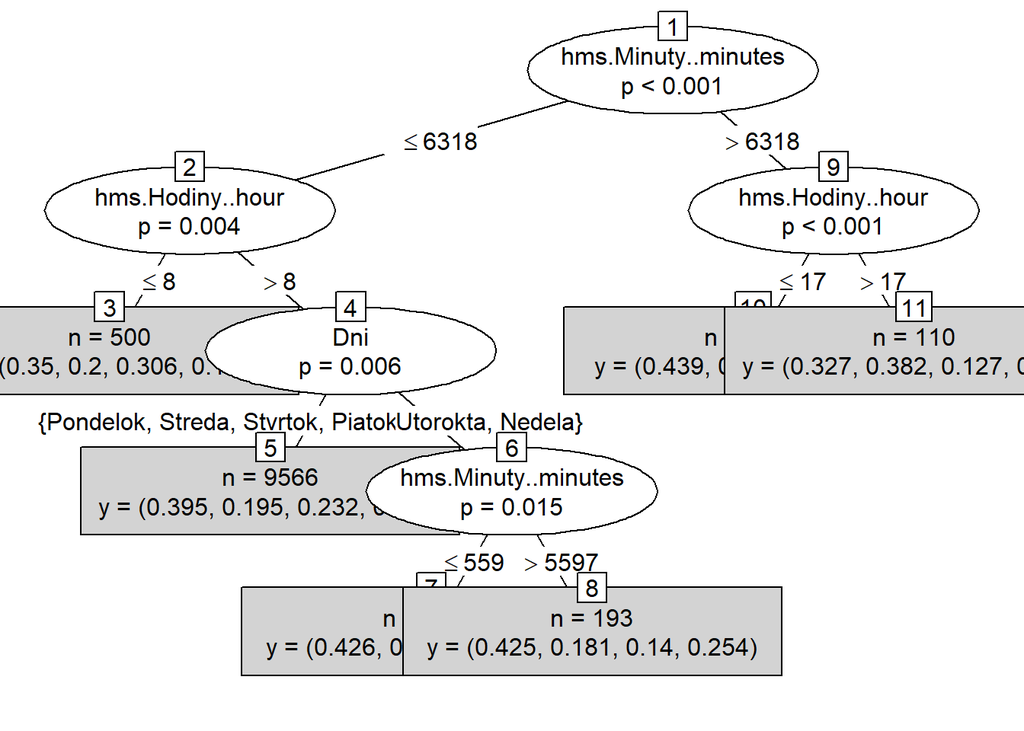

```r
spojeneTabulky_1_1.tren_1 = spojeneTabulky_1_1[Vzorka==1,]
spojeneTabulky_1_1.test_1 = spojeneTabulky_1_1[Vzorka==2,]


myFormula = Polozky ~  Dni + hms.Minuty..minutes + hms.Hodiny..hour
spojeneTabulky_1_1.ctree = ctree(myFormula, data = spojeneTabulky_1_1.tren_1)
plot(spojeneTabulky_1_1.ctree, type="simple")
```

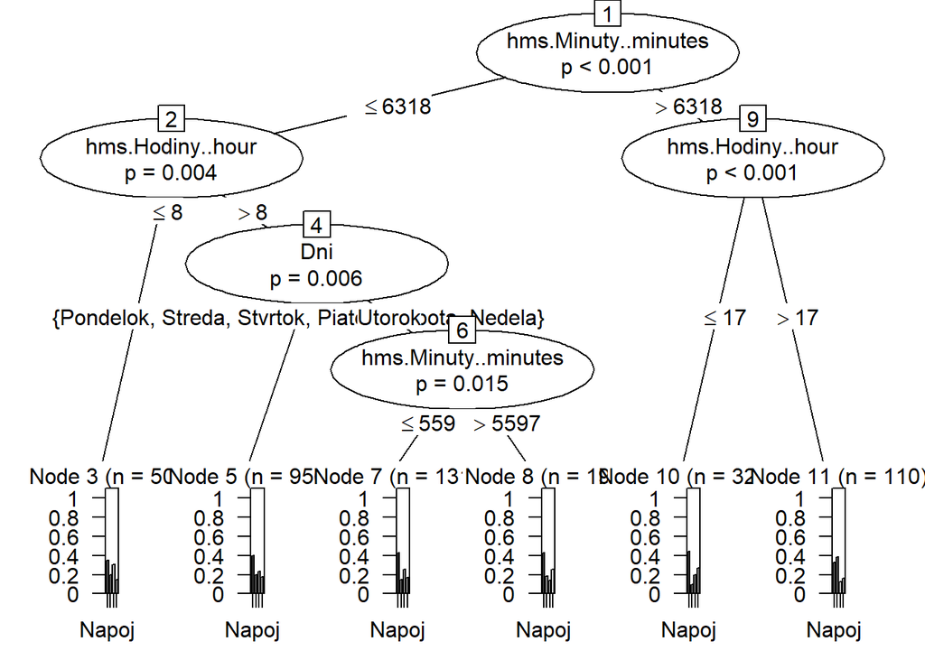

```r
plot(spojeneTabulky_1_1.ctree)
```

```r
table(predict(spojeneTabulky_1_1.ctree),spojeneTabulky_1_1.tren_1$Polozky)
```

```
##
##                  Napoj OstatnePolozky PecivoNesladke Sladkosti
##   Napoj           6027           2505           3387      2911
##   OstatnePolozky    36             42             14        18
##   PecivoNesladke     0              0              0         0
##   Sladkosti          0              0              0         0
```

```r
table(predict(spojeneTabulky_1_1.ctree, newdata=spojeneTabulky_1_1.test_1), spojeneTabulky_1_1.test_1$Polozky)
```

```
##
##                  Napoj OstatnePolozky PecivoNesladke Sladkosti
##   Napoj           2560           1004           1452      1238
##   OstatnePolozky    14             23              6         7
##   PecivoNesladke     0              0              0         0
##   Sladkosti          0              0              0         0
```

### Asociacne pravidla

najprv si este raz nacitame data zo suboru ale s podporou funkcie specialne urcenej na tento typ prikladu z baliku arules a arulesViz

```r
library(arules)
```

```r
library(arulesViz)
selektovaneTransakcie = read.transactions("BreadBasket_DMS.csv",format="single",cols=c(3,4),sep=",")
summary(itemFrequency(selektovaneTransakcie))
```

```
##      Min.   1st Qu.    Median      Mean   3rd Qu.      Max.
## 0.0001512 0.0002646 0.0013607 0.0200871 0.0146659 0.4820079
```

Podla sumarizacnej tabulky vidime, ze maximalnu frekvenciu poloziek dosahujeme pri bode 0,4820079. Teraz vypocitame minimalnu podporu(support) tak, ze podelime 30 (lebo vsetkych poloziek je cez 90, tak aspon jednu tretinu uspesne prehladali) s dlzkou celkoveho obsahu premennej selektovaneTransakcie

```r
30/length(selektovaneTransakcie)
```

```
## [1] 0.004535833
```

Pomocou algoritmu apriori zanalizujeme transakcie ako vstupne parametre urcime podpora = 0,0045 a spolahlivost = 50% = 0,5

```r
pravidla <- apriori(selektovaneTransakcie,parameter=list(support=0.0045,confidence=.5))
```

```
## Apriori
##
## Parameter specification:
##  confidence minval smax arem  aval originalSupport maxtime support minlen
##         0.5    0.1    1 none FALSE            TRUE       5  0.0045      1
##  maxlen target   ext
##      10  rules FALSE
##
## Algorithmic control:
##  filter tree heap memopt load sort verbose
##     0.1 TRUE TRUE  FALSE TRUE    2    TRUE
##
## Absolute minimum support count: 29
##
## set item appearances ...[0 item(s)] done [0.00s].
## set transactions ...[104 item(s), 6614 transaction(s)] done [0.00s].
## sorting and recoding items ... [39 item(s)] done [0.00s].
## creating transaction tree ... done [0.00s].
## checking subsets of size 1 2 3 4 done [0.00s].
## writing ... [20 rule(s)] done [0.00s].
## creating S4 object  ... done [0.00s].
```

```r
inspect(pravidla)
```

```
##      lhs                     rhs      support     confidence lift
## [1]  {Hearty & Seasonal}  => {Coffee} 0.005443000 0.5454545  1.131630
## [2]  {Jammie Dodgers}     => {Coffee} 0.007257333 0.5161290  1.070790
## [3]  {Salad}              => {Coffee} 0.007862111 0.6117647  1.269201
## [4]  {Tiffin}             => {Coffee} 0.010583611 0.5468750  1.134577
## [5]  {Spanish Brunch}     => {Coffee} 0.014061083 0.6326531  1.312537
## [6]  {Scone}              => {Coffee} 0.018445721 0.5422222  1.124924
## [7]  {Toast}              => {Coffee} 0.025703054 0.7296137  1.513697
## [8]  {Alfajores}          => {Coffee} 0.022376777 0.5522388  1.145705
## [9]  {Juice}              => {Coffee} 0.021318415 0.5300752  1.099723
## [10] {Hot chocolate}      => {Coffee} 0.027214998 0.5263158  1.091924
## [11] {Medialuna}          => {Coffee} 0.032960387 0.5751979  1.193337
## [12] {Cookies}            => {Coffee} 0.029785304 0.5267380  1.092800
## [13] {NONE}               => {Coffee} 0.041729664 0.5810526  1.205484
## [14] {Sandwich}           => {Coffee} 0.042334442 0.5679513  1.178303
```

[output cut: 27 more lines]

Grafy

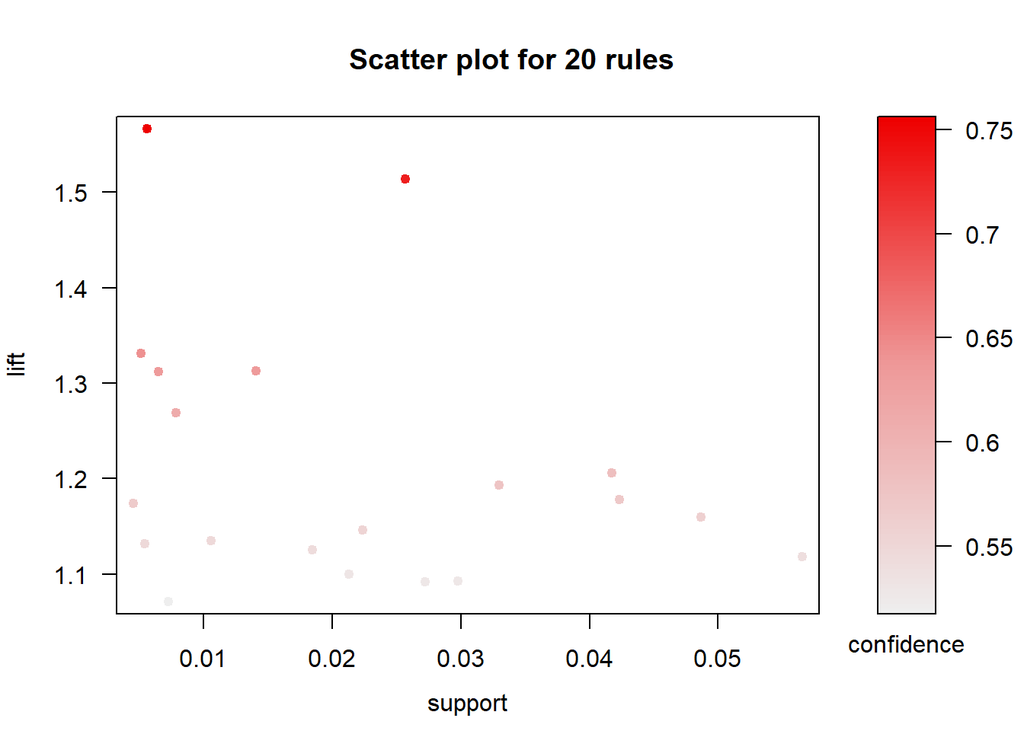

```r
plot(pravidla, measure=c("support","lift"), shading="confidence")
```

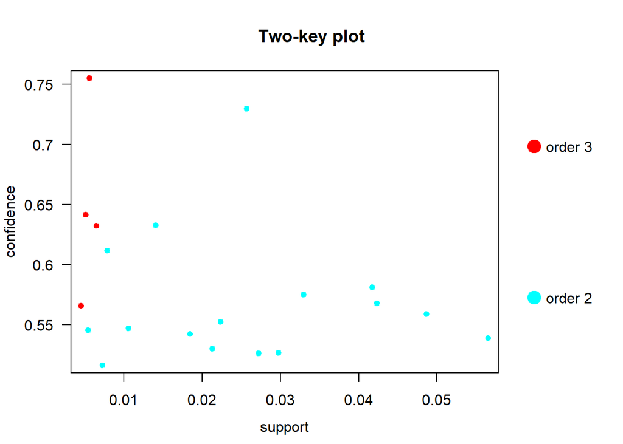

```r
plot(pravidla, method = "two-key plot")
```

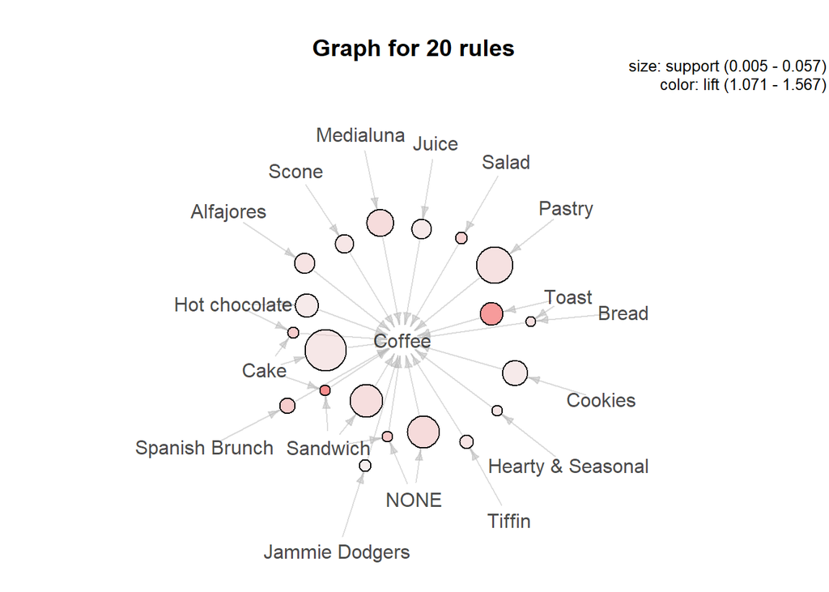

```r
plot(pravidla, method="graph")
```

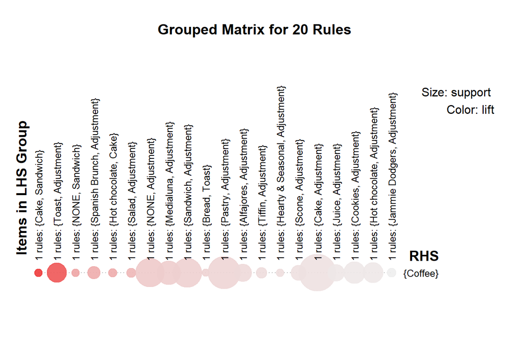

```r
plot(pravidla, method="grouped")
```

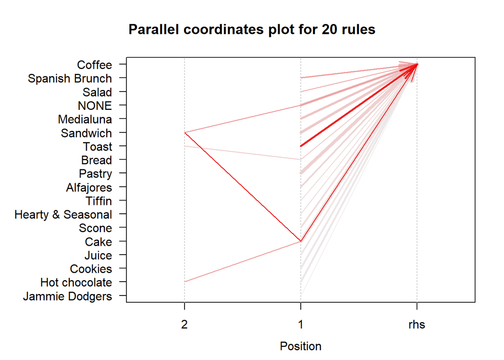

```r
plot(pravidla, method="paracoord", control=list(reorder=TRUE))
```